# Atividade 6

# Análise diagnóstica em modelos de regressão linear

## Questão 1

Primeiro, vamos fazer uma breve análise exploratória inicial, para entender melhor qual a relacão entre as covariáveis e a variável resposta.

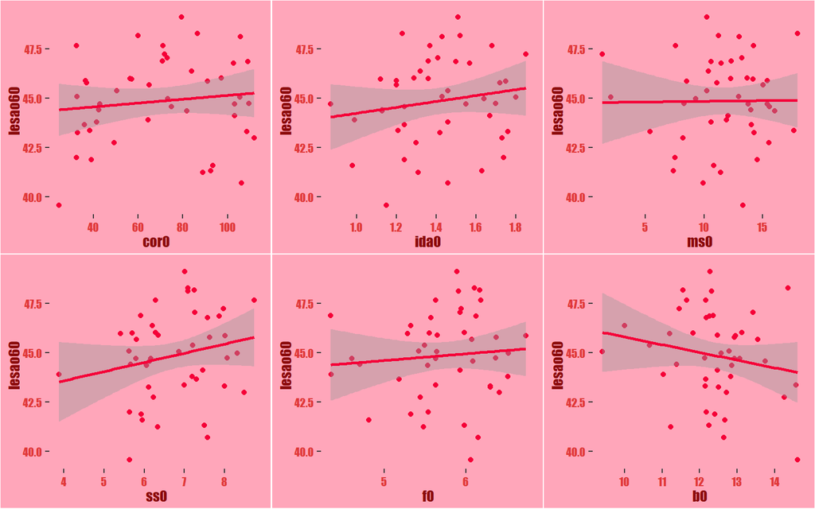

```r
plot_grid(g1,g2,g3,g4,g5,g6)
```

Nessa primeira análise, já pudemos observar a presença de alguns outliers, que vão ser tratados posteriormente nessa atividade.

Segundo, vamos ajustar um modelo com todas as covariáveis que temos disponível, depois vamos fazer uma análise diagnóstica, baseada nesse ajuste, e realizar, caso necessário, as devidas correções.

```r
fit <- lm(lesao60~., data=tb)
pander(summary(fit))
```

|  | Estimate | Std. Error | t value | Pr(>\|t\|) |
| --- | --- | --- | --- | --- |
| **(Intercept)** | 43.26 | 4.946 | 8.746 | 1.234e-10 |
| **cor0** | 0.003394 | 0.01273 | 0.2667 | 0.7911 |
| **ida0** | 3.646 | 2.834 | 1.286 | 0.2061 |
| **ms0** | 0.4565 | 0.1698 | 2.688 | 0.01061 |
| **ss0** | 0.7343 | 0.5257 | 1.397 | 0.1706 |
| **f0** | -0.2489 | 0.9422 | -0.2641 | 0.7931 |
| **b0** | -1.019 | 0.4256 | -2.396 | 0.02162 |

Fitting linear model: lesao60 ~ .

| Observations | Residual Std. Error | $R^2$ | Adjusted $R^2$ |
| --- | --- | --- | --- |
| 45 | 2.104 | 0.2322 | 0.1109 |

Como pudemos observar, as covariáveis “cor0” e “f0” não são significativas para o nosso modelo inicial, então vamos tentar um novo ajuste, utilizando uma nova variável explicativa, que vai ser “f0/cor0”, já que, parece fazer sentido para o nosso modelo.

```r
tb$fc0 <- tb$f0/tb$cor0
fit <- lm(lesao60~., data=tb)
pander(summary(fit))
```

|  | Estimate | Std. Error | t value | Pr(>\|t\|) |
| --- | --- | --- | --- | --- |
| **(Intercept)** | 45.64 | 4.747 | 9.614 | 1.326e-11 |
| **cor0** | -0.07618 | 0.0345 | -2.208 | 0.0335 |
| **ida0** | 3.78 | 2.663 | 1.419 | 0.1642 |
| **ms0** | 0.3617 | 0.1642 | 2.203 | 0.03389 |
| **ss0** | 0.567 | 0.4986 | 1.137 | 0.2628 |
| **f0** | 0.8687 | 0.995 | 0.873 | 0.3883 |
| **b0** | -0.7311 | 0.4167 | -1.755 | 0.0876 |
| **fc0** | -48.36 | 19.66 | -2.459 | 0.01872 |

Fitting linear model: lesao60 ~ .

| Observations | Residual Std. Error | $R^2$ | Adjusted $R^2$ |
| --- | --- | --- | --- |
| 45 | 1.977 | 0.34 | 0.2152 |

Vamos seguir nossa análise com esse novo modelo, que parece explicar melhor a variação da nossa variável dependente, já que tem um $R²$ maior. Agora, vamos retirar a variável independente “f0” que se mostrou a covariável menos significativa e fazer um novo ajuste.

```r
tb <- tb[,-c(5)]
fit <- lm(lesao60~., data=tb)
pander(summary(fit))
```

|  | Estimate | Std. Error | t value | Pr(>\|t\|) |
| --- | --- | --- | --- | --- |
| **(Intercept)** | 45.43 | 4.726 | 9.612 | 1.012e-11 |
| **cor0** | -0.0631 | 0.03097 | -2.037 | 0.04865 |
| **ida0** | 4.63 | 2.471 | 1.874 | 0.06867 |
| **ms0** | 0.3923 | 0.1599 | 2.454 | 0.01884 |
| **ss0** | 0.7329 | 0.4595 | 1.595 | 0.119 |
| **b0** | -0.6644 | 0.4083 | -1.627 | 0.112 |
| **fc0** | -40.52 | 17.44 | -2.323 | 0.02561 |

Fitting linear model: lesao60 ~ .

| Observations | Residual Std. Error | $R^2$ | Adjusted $R^2$ |
| --- | --- | --- | --- |
| 45 | 1.971 | 0.3264 | 0.2201 |

```r
pander(anova(fit))
```

Analysis of Variance Table

|  | Df | Sum Sq | Mean Sq | F value | Pr(>F) |
| --- | --- | --- | --- | --- | --- |
| **cor0** | 1 | 3.164 | 3.164 | 0.8145 | 0.3725 |
| **ida0** | 1 | 3.642 | 3.642 | 0.9375 | 0.339 |
| **ms0** | 1 | 10.16 | 10.16 | 2.616 | 0.1141 |
| **ss0** | 1 | 1.862 | 1.862 | 0.4794 | 0.4929 |
| **b0** | 1 | 31.74 | 31.74 | 8.17 | 0.006875 |
| **fc0** | 1 | 20.97 | 20.97 | 5.398 | 0.02561 |
| **Residuals** | 38 | 147.6 | 3.884 | NA | NA |

Pudemos observar que, mesmo o $R²$ tendo diminuido um pouco quando removemos “f0”, nosso $R²$ ajustado aumentou.

O modelo final escolhido para prosseguirmos com a análise de diagnóstico será esse, que mesmo possuindo algumas variáveis não significativas a 5%, explica melhor a variação da variável dependente “lesao60”. Então, vamos ser flexíveis e iremos essas covariáveis.

Dito isso, vamos repetir o mesmo plot do início e, finalmente, dar sequência a nossa análise de diagnóstica mais completa.

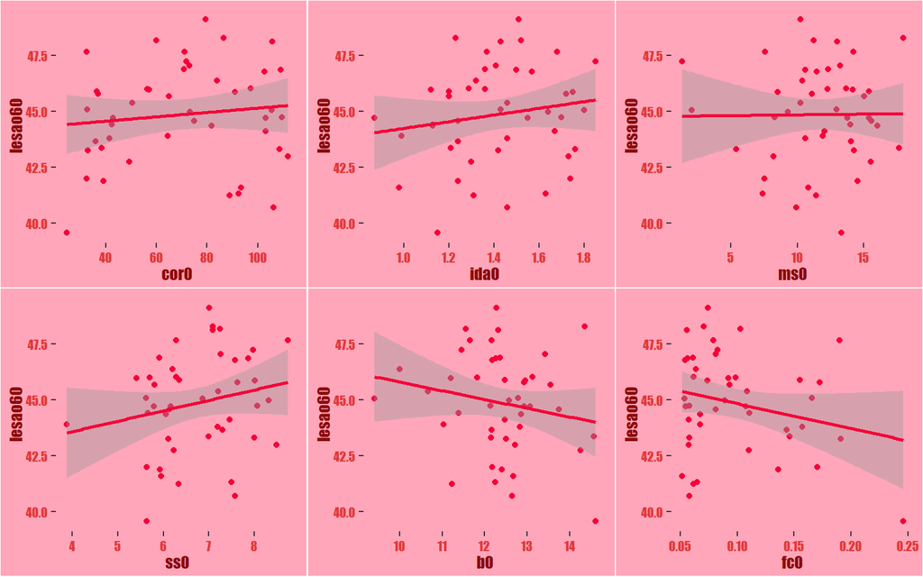

```r
plot_grid(g1,g2,g3,g4,g5,g6)
```

Agora, vamos plotar os quatro gráficos principais para a nossa análise de diagnóstico: Gráfico dos resíduos contra os valores ajustados, gráfico dos resíduos absolutos contra os valores ajustados, gráfico qq-norm e gráfico de alavancagem.

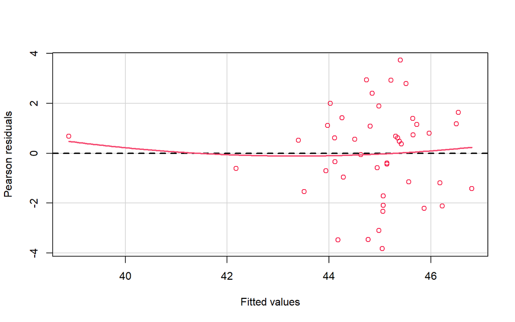